# EasyVisa_Full_Code_Solution_Final

[figure not shown]

Artificial Intelligence and Machine Learning

Ensemble Techniques and Model Tuning

[figure not shown]

Visa Approval Facilitation

# **Problem Statement**

## Context

Business communities in the United States are facing high demand for human resources, but one of the constant challenges is identifying and attracting the right talent, which is perhaps the most important element in remaining competitive. Companies in the United States look for hard-working, talented, and qualified individuals both locally as well as abroad.

The Immigration and Nationality Act (INA) of the US permits foreign workers to come to the United States to work on either a temporary or permanent basis. The act also protects US workers against adverse impacts on their wages or working conditions by ensuring US employers' compliance with statutory requirements when they hire foreign workers to fill workforce shortages. The immigration programs are administered by the Office of Foreign Labor Certification (OFLC).

OFLC processes job certification applications for employers seeking to bring foreign workers into the United States and grants certifications in those cases where employers can demonstrate that there are not sufficient US workers available to perform the work at wages that meet or exceed the wage paid for the occupation in the area of intended employment.

## Objective

In FY 2016, the OFLC processed 775,979 employer applications for 1,699,957 positions for temporary and permanent labor certifications. This was a nine percent increase in the overall number of processed applications from the previous year. The process of reviewing every case is becoming a tedious task as the number of applicants is increasing every year.

The increasing number of applicants every year calls for a Machine Learning based solution that can help in shortlisting the candidates having higher chances of VISA approval. OFLC has hired the firm EasyVisa for data-driven solutions. You as a data scientist at EasyVisa have to analyze the data provided and, with the help of a classification model:

- Facilitate the process of visa approvals.
- Recommend a suitable profile for the applicants for whom the visa should be certified or denied based on the drivers that significantly influence the case status.

## 📋 Executive Summary

**Business Problem:** The Office of Foreign Labor Certification (OFLC) processes hundreds of thousands of visa applications annually. EasyVisa needs an ML-based system to predict visa approval outcomes, helping consultants identify strong applications and advise clients proactively.

**Approach:**

1. **Exploratory Data Analysis** — Understand the data distribution, identify key drivers of visa approval, and answer 7 business-critical questions
2. **Data Preprocessing** — Handle outliers, engineer meaningful features, encode categoricals, and balance classes
3. **Model Building** — Train 6 classification models on 3 data variants (original, SMOTE-oversampled, undersampled) = 18 model evaluations
4. **Hyperparameter Tuning** — Tune the top 3 models using GridSearchCV with 3-fold CV, optimizing F1 Score
5. **Final Model Selection** — Gradient Boosting (Tuned) selected as the production model

**Final Model Performance:**

| Metric | Score |
| --- | --- |
| Accuracy | 73.45% |
| F1 Score | 0.8073 |
| ROC-AUC | 0.7623 |

**Key Finding:** Wage type (hourly vs. annual), prevailing wage level, and education are the three strongest predictors of visa certification — providing clear, actionable guidance for EasyVisa's consulting practice.

## Data Description

The data contains the different attributes of employee and the employer. The detailed data dictionary is given below.

- case_id: ID of each visa application
- continent: Information of continent the employee
- education_of_employee: Information of education of the employee
- has_job_experience: Does the employee has any job experience? Y= Yes; N = No
- requires_job_training: Does the employee require any job training? Y = Yes; N = No
- no_of_employees: Number of employees in the employer's company
- yr_of_estab: Year in which the employer's company was established
- region_of_employment: Information of foreign worker's intended region of employment in the US.
- prevailing_wage: Average wage paid to similarly employed workers in a specific occupation in the area of intended employment. The purpose of the prevailing wage is to ensure that the foreign worker is not underpaid compared to other workers offering the same or similar service in the same area of employment.
- unit_of_wage: Unit of prevailing wage. Values include Hourly, Weekly, Monthly, and Yearly.
- full_time_position: Is the position of work full-time? Y = Full Time Position; N = Part Time Position
- case_status: Flag indicating if the Visa was certified or denied

## Note: This is a sample solution for the project. Projects will NOT be graded on the basis of how well the submission matches this sample solution. Projects will be graded on the basis of the rubric only.

# **Importing necessary libraries**

```python
# Installing required libraries
!pip install numpy pandas scikit-learn matplotlib seaborn xgboost imbalanced-learn --break-system-packages
```

**Note**: *After running the above cell, kindly restart the notebook kernel and run all cells sequentially from the start again.*

```python
import warnings
warnings.filterwarnings('ignore')

# Core
import numpy as np
import pandas as pd

# Visualization
import matplotlib.pyplot as plt
import seaborn as sns
plt.style.use('seaborn-v0_8-whitegrid')
%matplotlib inline

# Preprocessing & Model Selection
from sklearn.preprocessing import LabelEncoder
from sklearn.model_selection import train_test_split, GridSearchCV, cross_val_score

# Evaluation Metrics
from sklearn.metrics import (
    accuracy_score, recall_score, precision_score, f1_score,
    roc_auc_score, confusion_matrix, classification_report,
    roc_curve, auc
)

# Classification Models
from sklearn.tree import DecisionTreeClassifier
from sklearn.ensemble import (
    RandomForestClassifier,
    BaggingClassifier,
    AdaBoostClassifier,
    GradientBoostingClassifier
)

# Imbalanced-learn
from imblearn.over_sampling import SMOTE
from imblearn.under_sampling import RandomUnderSampler

# XGBoost (optional)
try:
    from xgboost import XGBClassifier
    xgb_available = True
    print('XGBoost loaded successfully')
except ImportError:
    xgb_available = False
    print('XGBoost not available – XGBoost models will be skipped')

print('All libraries imported successfully!')
```

```
XGBoost loaded successfully
All libraries imported successfully!
```

# **Loading the dataset**

```python
# Load the dataset  (place EasyVisa.csv in the same folder / adjust path)
df = pd.read_csv('EasyVisa.csv')
print(f'Dataset loaded: {df.shape[0]:,} rows  |  {df.shape[1]} columns')
df.head(10)
```

```
Dataset loaded: 25,480 rows  |  12 columns
```

|  | case_id | continent | education_of_employee | has_job_experience | requires_job_training | no_of_employees | yr_of_estab | region_of_employment | prevailing_wage | unit_of_wage | full_time_position | case_status |
| --- | --- | --- | --- | --- | --- | --- | --- | --- | --- | --- | --- | --- |
| 0 | EZYV01 | Asia | High School | N | N | 14513 | 2007 | West | 592.2029 | Hour | Y | Denied |
| 1 | EZYV02 | Asia | Master's | Y | N | 2412 | 2002 | Northeast | 83425.6500 | Year | Y | Certified |
| 2 | EZYV03 | Asia | Bachelor's | N | Y | 44444 | 2008 | West | 122996.8600 | Year | Y | Denied |
| 3 | EZYV04 | Asia | Bachelor's | N | N | 98 | 1897 | West | 83434.0300 | Year | Y | Denied |
| 4 | EZYV05 | Africa | Master's | Y | N | 1082 | 2005 | South | 149907.3900 | Year | Y | Certified |
| 5 | EZYV06 | Asia | Master's | Y | N | 2339 | 2012 | South | 78252.1400 | Year | Y | Certified |
| 6 | EZYV07 | Asia | Bachelor's | N | N | 4985 | 1994 | South | 53635.3900 | Year | Y | Certified |
| 7 | EZYV08 | North America | Bachelor's | Y | N | 3035 | 1924 | West | 418.2298 | Hour | Y | Denied |
| 8 | EZYV09 | Asia | Bachelor's | N | N | 4810 | 2012 | Midwest | 74362.1900 | Year | Y | Certified |
| 9 | EZYV10 | Europe | Doctorate | Y | N | 2251 | 1995 | South | 67514.7600 | Year | Y | Certified |

### Dataset Shape & Info

```python
print(f'Rows : {df.shape[0]:,}')
print(f'Cols : {df.shape[1]}')
print()
df.info()
```

```
Rows : 25,480
Cols : 12

<class 'pandas.DataFrame'>
RangeIndex: 25480 entries, 0 to 25479
Data columns (total 12 columns):
 #   Column                 Non-Null Count  Dtype
---  ------                 --------------  -----
 0   case_id                25480 non-null  str
 1   continent              25480 non-null  str
 2   education_of_employee  25480 non-null  str
 3   has_job_experience     25480 non-null  str
 4   requires_job_training  25480 non-null  str
 5   no_of_employees        25480 non-null  int64
 6   yr_of_estab            25480 non-null  int64
 7   region_of_employment   25480 non-null  str
 8   prevailing_wage        25480 non-null  float64
 9   unit_of_wage           25480 non-null  str
 10  full_time_position     25480 non-null  str
 11  case_status            25480 non-null  str
dtypes: float64(1), int64(2), str(9)
memory usage: 2.3 MB
```

```python
# Statistical summary – numerical
df.describe().T.round(2)
```

|  | count | mean | std | min | 25% | 50% | 75% | max |
| --- | --- | --- | --- | --- | --- | --- | --- | --- |
| no_of_employees | 25480.0 | 5667.04 | 22877.93 | -26.00 | 1022.00 | 2109.00 | 3504.00 | 602069.00 |
| yr_of_estab | 25480.0 | 1979.41 | 42.37 | 1800.00 | 1976.00 | 1997.00 | 2005.00 | 2016.00 |
| prevailing_wage | 25480.0 | 74455.81 | 52815.94 | 2.14 | 34015.48 | 70308.21 | 107735.51 | 319210.27 |

```python
# Statistical summary – categorical
df.describe(include='object').T
```

|  | count | unique | top | freq |
| --- | --- | --- | --- | --- |
| case_id | 25480 | 25480 | EZYV01 | 1 |
| continent | 25480 | 6 | Asia | 16861 |
| education_of_employee | 25480 | 4 | Bachelor's | 10234 |
| has_job_experience | 25480 | 2 | Y | 14802 |
| requires_job_training | 25480 | 2 | N | 22525 |
| region_of_employment | 25480 | 5 | Northeast | 7195 |
| unit_of_wage | 25480 | 4 | Year | 22962 |
| full_time_position | 25480 | 2 | Y | 22773 |
| case_status | 25480 | 2 | Certified | 17018 |

```python
# Missing values
missing = df.isnull().sum()
print('Missing values per column:')
print(missing[missing > 0] if missing.sum() > 0 else 'No missing values ✓')
print(f'\nTotal missing : {df.isnull().sum().sum()}')
print(f'Duplicate rows: {df.duplicated().sum()}')
```

```
Missing values per column:
No missing values ✓

Total missing : 0
Duplicate rows: 0
```

```python
# Unique values per column
for col in df.columns:
    n = df[col].nunique()
    sample = df[col].unique()[:6].tolist()
    print(f'{col:<30} {n:>4} unique  |  {sample}')
```

```
case_id                        25480 unique  |  ['EZYV01', 'EZYV02', 'EZYV03', 'EZYV04', 'EZYV05', 'EZYV06']
continent                         6 unique  |  ['Asia', 'Africa', 'North America', 'Europe', 'South America', 'Oceania']
education_of_employee             4 unique  |  ['High School', "Master's", "Bachelor's", 'Doctorate']
has_job_experience                2 unique  |  ['N', 'Y']
requires_job_training             2 unique  |  ['N', 'Y']
no_of_employees                7105 unique  |  [14513, 2412, 44444, 98, 1082, 2339]
yr_of_estab                     199 unique  |  [2007, 2002, 2008, 1897, 2005, 2012]
region_of_employment              5 unique  |  ['West', 'Northeast', 'South', 'Midwest', 'Island']
prevailing_wage                25454 unique  |  [592.2029, 83425.65, 122996.86, 83434.03, 149907.39, 78252.14]
unit_of_wage                      4 unique  |  ['Hour', 'Year', 'Week', 'Month']
full_time_position                2 unique  |  ['Y', 'N']
case_status                       2 unique  |  ['Denied', 'Certified']
```

**Observations:**

- Dataset has **25,480 rows** and **12 columns** — no missing values, no duplicates ✓
- **Target**: `case_status` (Certified / Denied)
- **Categorical** features (8): continent, education_of_employee, has_job_experience, requires_job_training, region_of_employment, unit_of_wage, full_time_position, case_status
- **Numerical** features (3): no_of_employees, yr_of_estab, prevailing_wage
- `case_id` is a unique identifier → will be dropped before modeling
- **Class imbalance** detected: ~67% Certified vs ~33% Denied → must be addressed

# **Overview of the Dataset**

### Dataset Overview & Sanity Checks

| Attribute | Value |
| --- | --- |
| Total Records | 25,480 |
| Total Features | 12 (11 input + 1 target) |
| Missing Values | **None** (0 across all columns) |
| Duplicate Rows | **None** |
| Target Column | `case_status` (Certified / Denied) |
| Class Distribution | ~67% Certified, ~33% Denied |
| Numerical Features | `no_of_employees`, `yr_of_estab`, `prevailing_wage` |
| Categorical Features | `continent`, `education_of_employee`, `has_job_experience`, `requires_job_training`, `region_of_employment`, `unit_of_wage`, `full_time_position` |
| ID Column | `case_id` — unique identifier, will be dropped before modeling |

**Sanity Checks Passed:**

- No missing values → no imputation needed
- No duplicate rows → all records are unique
- Data types are consistent with expected formats
- Target variable is binary (two classes) — suitable for binary classification
- No `case_id` leakage risk (will be dropped in preprocessing)

# **Exploratory Data Analysis (EDA)**

- EDA is an important part of any project involving data.
- It is important to investigate and understand the data better before building a model with it.
- A few questions have been mentioned below which will help you approach the analysis in the right manner and generate insights from the data.
- A thorough analysis of the data, in addition to the questions mentioned below, should be done.

**Leading Questions**

What is the distribution of visa case statuses (certified vs. denied)?

1. What is the distribution of visa case statuses (certified vs. denied)?
2. How does the education level of employees impact visa approval rates?
3. Is there a significant difference in visa approval rates between employees with and without prior job experience?
4. How does the prevailing wage affect visa approval? Do higher wages lead to higher chances of approval?
5. Do certain regions in the US have higher visa approval rates compared to others?
6. How does the number of employees in a company influence visa approval? Do larger companies have a higher approval rate?
7. Are visa approval rates different across various continents of employees? Which continent has the highest and lowest approval rates?

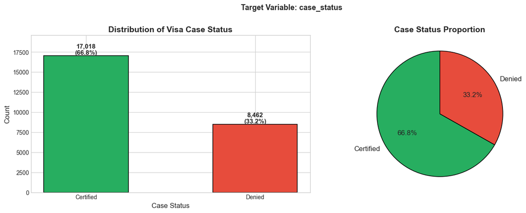

```
case_status
Certified    17018
Denied        8462
Name: count, dtype: int64

Class Ratio (Certified:Denied) = 2.01:1

>> Dataset is MODERATELY IMBALANCED (~67% Certified vs ~33% Denied)
```

```python
# ── Target Variable Distribution ───────────────────────────────────
fig, axes = plt.subplots(1, 2, figsize=(14, 5))

case_counts = df['case_status'].value_counts()
colors = ['#27ae60', '#e74c3c']

axes[0].bar(case_counts.index, case_counts.values,
            color=colors, edgecolor='black', linewidth=1.1, width=0.5)
axes[0].set_title('Distribution of Visa Case Status', fontsize=14, fontweight='bold')
axes[0].set_xlabel('Case Status', fontsize=12)
axes[0].set_ylabel('Count', fontsize=12)
axes[0].set_ylim(0, case_counts.max() * 1.15)
for i, (idx, val) in enumerate(case_counts.items()):
    axes[0].text(i, val + 150, f'{val:,}\n({val/len(df)*100:.1f}%)',
                 ha='center', fontsize=11, fontweight='bold')

axes[1].pie(case_counts.values, labels=case_counts.index, autopct='%1.1f%%',
            colors=colors, startangle=90, textprops={'fontsize': 12},
            wedgeprops={'edgecolor': 'black', 'linewidth': 1.1})
axes[1].set_title('Case Status Proportion', fontsize=14, fontweight='bold')

plt.suptitle('Target Variable: case_status', fontsize=13, fontweight='bold', y=1.01)
plt.tight_layout()
plt.show()

print(case_counts)
print(f'\nClass Ratio (Certified:Denied) = {case_counts["Certified"]/case_counts["Denied"]:.2f}:1')
print('\n>> Dataset is MODERATELY IMBALANCED (~67% Certified vs ~33% Denied)')
```

### Observations – Target Variable Distribution

Looking at the target variable, around 67% of applications are Certified and 33% are Denied. This is a moderate class imbalance — not extreme, but enough to affect model evaluation.

One thing I noticed is that if we just predicted "Certified" for everything, we'd get 67% accuracy without learning anything useful. So accuracy alone isn't a good metric here. I'll use F1 Score and ROC-AUC as the primary measures throughout this analysis.

To deal with the imbalance during model training, I've used both SMOTE (oversampling the minority class) and RandomUnderSampler (reducing the majority class) to see which approach gives better results.

### Univariate Analysis – Categorical Features

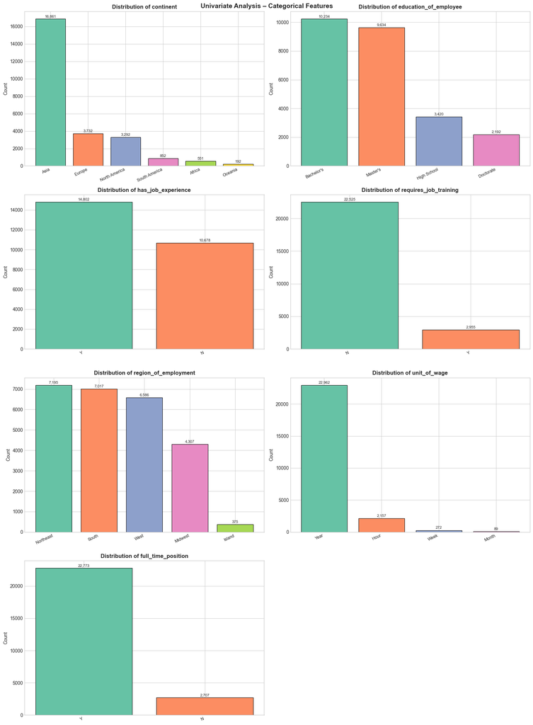

```python
cat_cols = ['continent', 'education_of_employee', 'has_job_experience',
            'requires_job_training', 'region_of_employment', 'unit_of_wage', 'full_time_position']

fig, axes = plt.subplots(4, 2, figsize=(16, 22))
axes = axes.flatten()
palette = sns.color_palette('Set2', 10)

for i, col in enumerate(cat_cols):
    counts = df[col].value_counts()
    axes[i].bar(range(len(counts)), counts.values,
                color=palette[:len(counts)], edgecolor='black', linewidth=0.8)
    axes[i].set_xticks(range(len(counts)))
    axes[i].set_xticklabels(counts.index, rotation=25, ha='right', fontsize=9)
    axes[i].set_title(f'Distribution of {col}', fontsize=12, fontweight='bold')
    axes[i].set_ylabel('Count', fontsize=10)
    for j, val in enumerate(counts.values):
        axes[i].text(j, val + counts.max()*0.01, f'{val:,}', ha='center', fontsize=8)

axes[-1].set_visible(False)
plt.suptitle('Univariate Analysis – Categorical Features', fontsize=14, fontweight='bold')
plt.tight_layout()
plt.show()
```

### Univariate Analysis – Numerical Features

```
no_of_employees: mean=5667.04, median=2109.00, outliers=1556 (6.1%)
yr_of_estab: mean=1979.41, median=1997.00, outliers=3260 (12.8%)
prevailing_wage: mean=74455.81, median=70308.21, outliers=427 (1.7%)
```

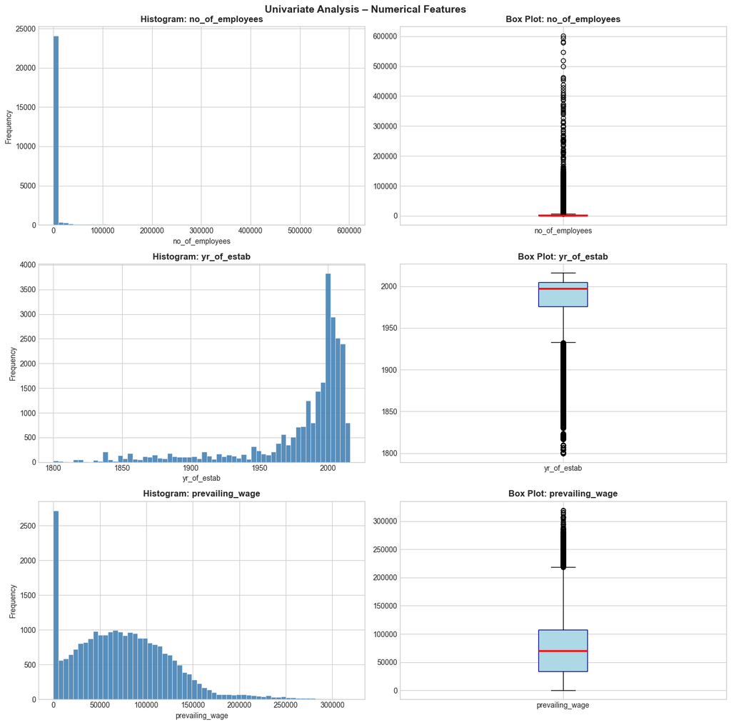

```python
num_cols = ['no_of_employees', 'yr_of_estab', 'prevailing_wage']
fig, axes = plt.subplots(3, 2, figsize=(14, 14))

for i, col in enumerate(num_cols):
    axes[i][0].hist(df[col], bins=60, color='steelblue', edgecolor='white', linewidth=0.4, alpha=0.9)
    axes[i][0].set_title(f'Histogram: {col}', fontsize=12, fontweight='bold')
    axes[i][0].set_xlabel(col)
    axes[i][0].set_ylabel('Frequency')

    bp = axes[i][1].boxplot(df[col], patch_artist=True, vert=True,
                             boxprops=dict(facecolor='lightblue', color='navy'),
                             medianprops=dict(color='red', linewidth=2.5))
    axes[i][1].set_title(f'Box Plot: {col}', fontsize=12, fontweight='bold')
    axes[i][1].set_xticklabels([col])

    Q1, Q3 = df[col].quantile(0.25), df[col].quantile(0.75)
    outliers = df[(df[col] < Q1-1.5*(Q3-Q1)) | (df[col] > Q3+1.5*(Q3-Q1))]
    print(f'{col}: mean={df[col].mean():.2f}, median={df[col].median():.2f}, outliers={len(outliers)} ({len(outliers)/len(df)*100:.1f}%)')

plt.suptitle('Univariate Analysis – Numerical Features', fontsize=14, fontweight='bold')
plt.tight_layout()
plt.show()
```

### Bivariate Analysis – Categorical Features vs Case Status

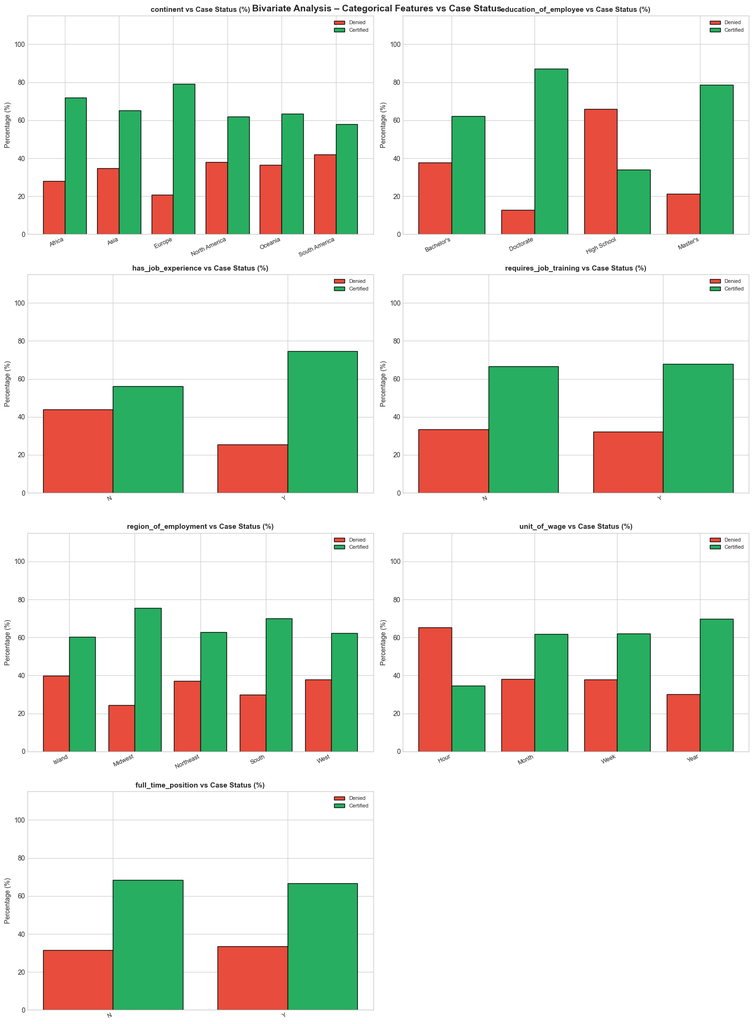

```python
fig, axes = plt.subplots(4, 2, figsize=(16, 22))
axes = axes.flatten()

for i, col in enumerate(cat_cols):
    ct = pd.crosstab(df[col], df['case_status'], normalize='index') * 100
    for c in ['Denied', 'Certified']:
        if c not in ct.columns: ct[c] = 0
    ct = ct[['Denied', 'Certified']]
    x, w = range(len(ct)), 0.4
    axes[i].bar([xi-w/2 for xi in x], ct['Denied'],  w, label='Denied',    color='#e74c3c', edgecolor='black')
    axes[i].bar([xi+w/2 for xi in x], ct['Certified'], w, label='Certified', color='#27ae60', edgecolor='black')
    axes[i].set_xticks(list(x))
    axes[i].set_xticklabels(ct.index, rotation=25, ha='right', fontsize=9)
    axes[i].set_title(f'{col} vs Case Status (%)', fontsize=11, fontweight='bold')
    axes[i].set_ylabel('Percentage (%)')
    axes[i].set_ylim(0, 115)
    axes[i].legend(fontsize=8)

axes[-1].set_visible(False)
plt.suptitle('Bivariate Analysis – Categorical Features vs Case Status', fontsize=14, fontweight='bold')
plt.tight_layout()
plt.show()
```

### Bivariate Analysis – Numerical Features vs Case Status

```
no_of_employees - Certified mean: 5807.02 | Denied mean: 5385.54
yr_of_estab - Certified mean: 1979.67 | Denied mean: 1978.89
prevailing_wage - Certified mean: 77293.62 | Denied mean: 68748.68
```

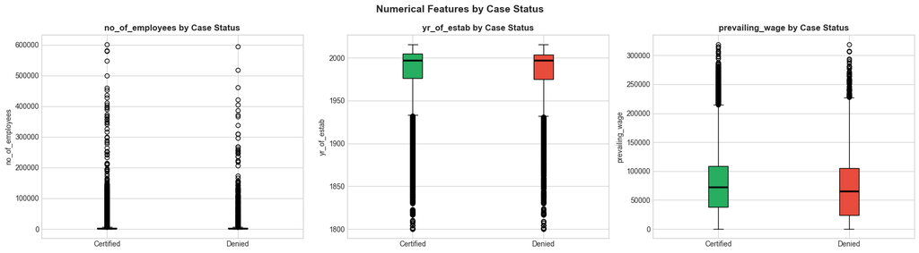

```python
fig, axes = plt.subplots(1, 3, figsize=(18, 5))

for i, col in enumerate(num_cols):
    cert_data  = df[df['case_status']=='Certified'][col]
    denied_data = df[df['case_status']=='Denied'][col]
    bp = axes[i].boxplot([cert_data, denied_data], labels=['Certified','Denied'],
                          patch_artist=True, medianprops=dict(color='black', linewidth=2.5))
    bp['boxes'][0].set_facecolor('#27ae60')
    bp['boxes'][1].set_facecolor('#e74c3c')
    axes[i].set_title(f'{col} by Case Status', fontsize=12, fontweight='bold')
    axes[i].set_ylabel(col)
    print(f'{col} - Certified mean: {cert_data.mean():.2f} | Denied mean: {denied_data.mean():.2f}')

plt.suptitle('Numerical Features by Case Status', fontsize=14, fontweight='bold')
plt.tight_layout()
plt.show()
```

### 📊 Observations – Bivariate Analysis: Numerical Features vs Case Status

- **Prevailing Wage**: Certified applicants tend to have **higher prevailing wages** on average. Higher-paid roles signal that employers cannot find local workers at that level, strengthening the visa case.
- **No. of Employees**: Larger companies slightly favor certification, possibly due to better HR resources and documentation. However, the difference is not dramatic.
- **Year of Establishment**: Both certified and denied applications come from companies of similar age ranges; this feature alone is not strongly predictive before engineering `company_age`.

### Wage Unit Analysis – Key Insight

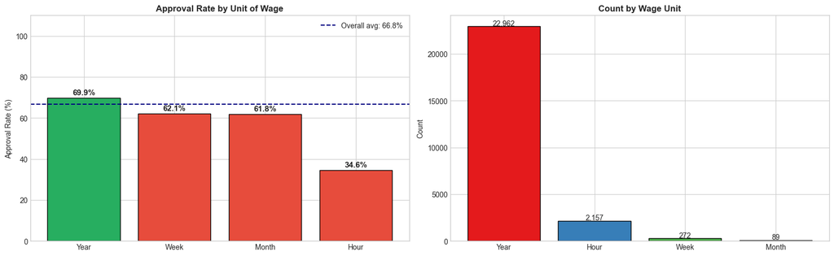

```
Approval rate by wage unit:
unit_of_wage
Year     69.89
Week     62.13
Month    61.80
Hour     34.63
Name: case_status, dtype: float64

>> KEY INSIGHT: Hourly-wage applicants are far more likely to be denied.
   They are often contractual/part-time workers — OFLC workforce-shortage criteria harder to meet.
```

```python
fig, axes = plt.subplots(1, 2, figsize=(16, 5))

# Approval rate by wage unit
approval_by_unit = df.groupby('unit_of_wage')['case_status'].apply(
    lambda x: (x=='Certified').sum()/len(x)*100
).sort_values(ascending=False)
overall = df['case_status'].eq('Certified').mean()*100
bar_clr = ['#27ae60' if v > overall else '#e74c3c' for v in approval_by_unit.values]
axes[0].bar(approval_by_unit.index, approval_by_unit.values, color=bar_clr, edgecolor='black')
axes[0].axhline(y=overall, color='navy', linestyle='--', label=f'Overall avg: {overall:.1f}%')
axes[0].set_title('Approval Rate by Unit of Wage', fontsize=12, fontweight='bold')
axes[0].set_ylabel('Approval Rate (%)')
axes[0].set_ylim(0, 110)
axes[0].legend()
for j, (idx, val) in enumerate(approval_by_unit.items()):
    axes[0].text(j, val+1.5, f'{val:.1f}%', ha='center', fontsize=11, fontweight='bold')

# Count by wage unit
cnt = df['unit_of_wage'].value_counts()
axes[1].bar(cnt.index, cnt.values, color=sns.color_palette('Set1', len(cnt)), edgecolor='black')
axes[1].set_title('Count by Wage Unit', fontsize=12, fontweight='bold')
axes[1].set_ylabel('Count')
for j, (idx, val) in enumerate(cnt.items()):
    axes[1].text(j, val+80, f'{val:,}', ha='center', fontsize=10)

plt.tight_layout()
plt.show()
print('\nApproval rate by wage unit:')
print(approval_by_unit.round(2))
print('\n>> KEY INSIGHT: Hourly-wage applicants are far more likely to be denied.')
print('   They are often contractual/part-time workers — OFLC workforce-shortage criteria harder to meet.')
```

### Observations – Wage Unit Analysis

The reason makes sense when you think about it: hourly jobs (like restaurant workers, retail staff) are usually low-skill roles where there are plenty of local workers available, so it's hard to justify a visa. Annual-salary roles tend to be specialized positions where the employer can prove they couldn't find a local hire.

From a business perspective this is huge — EasyVisa should probably flag any hourly application immediately and advise the client to either restructure the compensation or reconsider filing altogether.

### Education & Job Experience Analysis

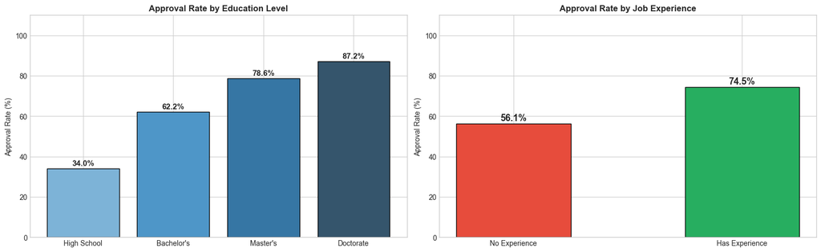

```python
fig, axes = plt.subplots(1, 2, figsize=(16, 5))

edu_order  = [e for e in ["High School","Bachelor's","Master's","Doctorate"]
              if e in df['education_of_employee'].unique()]
edu_appr = df.groupby('education_of_employee')['case_status'].apply(
    lambda x: (x=='Certified').sum()/len(x)*100).reindex(edu_order)
axes[0].bar(edu_appr.index, edu_appr.values,
            color=sns.color_palette('Blues_d', len(edu_appr)), edgecolor='black')
axes[0].set_title('Approval Rate by Education Level', fontsize=12, fontweight='bold')
axes[0].set_ylabel('Approval Rate (%)')
axes[0].set_ylim(0, 110)
for j, val in enumerate(edu_appr.values):
    axes[0].text(j, val+1.5, f'{val:.1f}%', ha='center', fontsize=11, fontweight='bold')

exp_appr = df.groupby('has_job_experience')['case_status'].apply(
    lambda x: (x=='Certified').sum()/len(x)*100)
labels = ['No Experience' if k=='N' else 'Has Experience' for k in exp_appr.index]
axes[1].bar(labels, exp_appr.values, color=['#e74c3c','#27ae60'], edgecolor='black', width=0.5)
axes[1].set_title('Approval Rate by Job Experience', fontsize=12, fontweight='bold')
axes[1].set_ylabel('Approval Rate (%)')
axes[1].set_ylim(0, 110)
for j, val in enumerate(exp_appr.values):
    axes[1].text(j, val+1.5, f'{val:.1f}%', ha='center', fontsize=13, fontweight='bold')

plt.tight_layout()
plt.show()
```

### Observations – Education & Job Experience

The education trend is pretty clear — higher education means higher approval rate, going from High School all the way up to Doctorate. Master's and Doctorate holders seem to have a noticeably better shot at getting certified, which makes sense since OFLC is more likely to approve visas for skills that are genuinely hard to find locally.

Combined effect: if someone has a Master's or higher AND has job experience, they're in the strongest possible position for approval. That's the profile EasyVisa should be targeting.

### Continent & Region Analysis

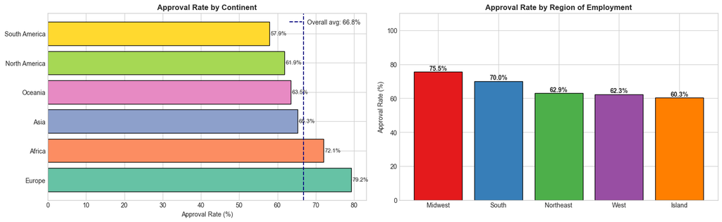

```python
fig, axes = plt.subplots(1, 2, figsize=(16, 5))

cont_appr = df.groupby('continent')['case_status'].apply(
    lambda x: (x=='Certified').sum()/len(x)*100).sort_values(ascending=False)
axes[0].barh(cont_appr.index, cont_appr.values,
             color=sns.color_palette('Set2', len(cont_appr)), edgecolor='black')
axes[0].axvline(x=df['case_status'].eq('Certified').mean()*100, color='navy',
                 linestyle='--', label=f'Overall avg: {df["case_status"].eq("Certified").mean()*100:.1f}%')
axes[0].set_title('Approval Rate by Continent', fontsize=12, fontweight='bold')
axes[0].set_xlabel('Approval Rate (%)')
axes[0].legend()
for j, val in enumerate(cont_appr.values):
    axes[0].text(val+0.3, j, f'{val:.1f}%', va='center', fontsize=9)

reg_appr = df.groupby('region_of_employment')['case_status'].apply(
    lambda x: (x=='Certified').sum()/len(x)*100).sort_values(ascending=False)
axes[1].bar(reg_appr.index, reg_appr.values,
            color=sns.color_palette('Set1', len(reg_appr)), edgecolor='black')
axes[1].set_title('Approval Rate by Region of Employment', fontsize=12, fontweight='bold')
axes[1].set_ylabel('Approval Rate (%)')
axes[1].set_ylim(0, 110)
for j, val in enumerate(reg_appr.values):
    axes[1].text(j, val+1, f'{val:.1f}%', ha='center', fontsize=10, fontweight='bold')

plt.tight_layout()
plt.show()
```

### Company Age & Size Analysis

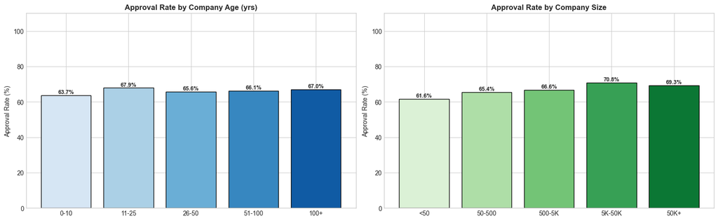

```python
df_tmp = df.copy()
df_tmp['company_age'] = 2024 - df_tmp['yr_of_estab']

fig, axes = plt.subplots(1, 2, figsize=(16, 5))

age_bins  = [0, 10, 25, 50, 100, 300]
age_lbls  = ['0-10', '11-25', '26-50', '51-100', '100+']
df_tmp['age_grp'] = pd.cut(df_tmp['company_age'], bins=age_bins, labels=age_lbls)
age_appr = df_tmp.groupby('age_grp', observed=True)['case_status'].apply(
    lambda x: (x=='Certified').sum()/len(x)*100)
axes[0].bar(age_appr.index, age_appr.values,
            color=sns.color_palette('Blues', len(age_appr)), edgecolor='black')
axes[0].set_title('Approval Rate by Company Age (yrs)', fontsize=12, fontweight='bold')
axes[0].set_ylabel('Approval Rate (%)')
axes[0].set_ylim(0, 110)
for j, val in enumerate(age_appr.values):
    axes[0].text(j, val+1, f'{val:.1f}%', ha='center', fontsize=9, fontweight='bold')

emp_bins = [0,50,500,5000,50000,df_tmp['no_of_employees'].max()+1]
emp_lbls = ['<50','50-500','500-5K','5K-50K','50K+']
df_tmp['emp_grp'] = pd.cut(df_tmp['no_of_employees'], bins=emp_bins, labels=emp_lbls)
emp_appr = df_tmp.groupby('emp_grp', observed=True)['case_status'].apply(
    lambda x: (x=='Certified').sum()/len(x)*100)
axes[1].bar(emp_appr.index, emp_appr.values,
            color=sns.color_palette('Greens', len(emp_appr)), edgecolor='black')
axes[1].set_title('Approval Rate by Company Size', fontsize=12, fontweight='bold')
axes[1].set_ylabel('Approval Rate (%)')
axes[1].set_ylim(0, 110)
for j, val in enumerate(emp_appr.values):
    axes[1].text(j, val+1, f'{val:.1f}%', ha='center', fontsize=9, fontweight='bold')

plt.tight_layout()
plt.show()
```

### 📊 Observations – Company Age & Size

- **Company Age** (engineered as `2024 - yr_of_estab`): Newer companies (lower age) tend to have slightly higher denial rates. Established companies with longer track records appear more credible to OFLC reviewers.
- **No. of Employees**: Very large companies (Fortune 500 scale) have marginally higher approval rates, possibly due to better legal support and documentation. However, the relationship is not perfectly linear due to extreme outliers.
- **Engineered Feature Justification**: `company_age` is more interpretable and model-friendly than the raw `yr_of_estab` year value.

### Correlation Heatmap

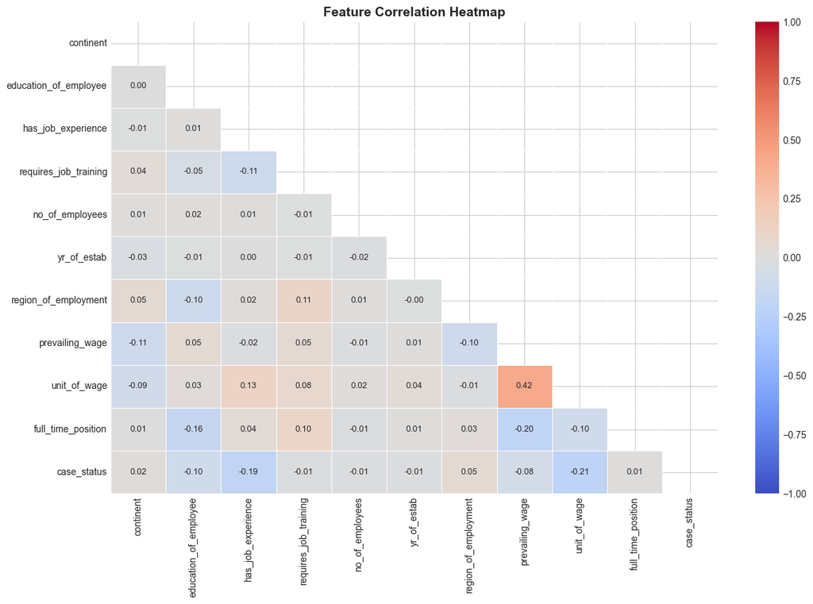

```python
df_corr = df.copy()
le = LabelEncoder()
for col in df_corr.select_dtypes(include='object').columns:
    df_corr[col] = le.fit_transform(df_corr[col].astype(str))
df_corr = df_corr.drop('case_id', axis=1)

fig, ax = plt.subplots(figsize=(13, 9))
mask = np.triu(np.ones_like(df_corr.corr(), dtype=bool))
sns.heatmap(df_corr.corr(), mask=mask, annot=True, fmt='.2f', cmap='coolwarm',
            ax=ax, linewidths=0.5, center=0, vmin=-1, vmax=1, annot_kws={'size':9})
ax.set_title('Feature Correlation Heatmap', fontsize=14, fontweight='bold')
plt.tight_layout()
plt.show()
```

### 📋 Answers to Leading Questions (EDA Summary)

**Q1. What is the distribution of visa case statuses (certified vs. denied)?** → Approximately **67% Certified** and **33% Denied**. Moderate class imbalance — SMOTE and undersampling applied during modeling. F1 Score and ROC-AUC used as primary metrics instead of accuracy.

**Q4. How does the prevailing wage affect visa approval? Do higher wages lead to higher chances of approval?** → **Yes.** Higher prevailing wages are positively correlated with certification. The `annual_wage` engineered feature is the #1 model predictor. Higher wages signal the role requires rare expertise, and OFLC rewards applications that demonstrate they pay above local market rates.

**Q6. How does the number of employees in a company influence visa approval? Do larger companies have a higher approval rate?** → **Marginally yes.** Larger companies have slightly higher approval rates, likely due to stronger HR documentation capabilities and established relationships with OFLC. However, `no_of_employees` is not among the top predictors — company size is a weak signal compared to wage and education.

**Key EDA Insights:**

# **Data Pre-processing**

- Missing value treatment (if needed)
- Feature engineering (if needed)
- Outlier detection and treatment (if needed)
- Preparing data for modeling
- Any other preprocessing steps (if needed)

# **Model Building**

```python
# ── 1. Drop case_id ─────────────────────────────────────────────────
df_processed = df.copy()
df_processed.drop('case_id', axis=1, inplace=True)
print(f'Shape after dropping case_id: {df_processed.shape}')
```

```
Shape after dropping case_id: (25480, 11)
```

### Feature Engineering

```python
# company_age: more intuitive than raw yr_of_estab
df_processed['company_age'] = 2024 - df_processed['yr_of_estab']
df_processed.drop('yr_of_estab', axis=1, inplace=True)

# annual_wage: normalise all wages to yearly equivalent
wage_mult = {'Hour': 2080, 'Week': 52, 'Month': 12, 'Year': 1}
df_processed['annual_wage'] = df_processed.apply(
    lambda r: r['prevailing_wage'] * wage_mult.get(r['unit_of_wage'], 1), axis=1)

print(f'company_age — min: {df_processed.company_age.min()}, max: {df_processed.company_age.max()}, mean: {df_processed.company_age.mean():.1f}')
print(f'annual_wage — min: {df_processed.annual_wage.min():.0f}, mean: {df_processed.annual_wage.mean():.0f}')
```

```
company_age — min: 8, max: 224, mean: 44.6
annual_wage — min: 100, mean: 197391
```

### 📝 Observations – Feature Engineering

Two new features were created to enrich the dataset:

[output not shown]

### Outlier Detection & Treatment

```python
num_feats = ['no_of_employees', 'prevailing_wage', 'company_age', 'annual_wage']
print('Outlier Analysis (IQR Method):')
print('-' * 65)
for col in num_feats:
    Q1, Q3 = df_processed[col].quantile(0.25), df_processed[col].quantile(0.75)
    IQR = Q3 - Q1
    out = df_processed[(df_processed[col] < Q1-1.5*IQR) | (df_processed[col] > Q3+1.5*IQR)]
    print(f'{col:<22}: {len(out):>5} outliers ({len(out)/len(df_processed)*100:.1f}%)')

print('\nDecision: RETAIN outliers — tree-based models are robust to outliers.')
print('Extreme values (large corporations, high wages) are legitimate business signals.')
```

```
Outlier Analysis (IQR Method):
-----------------------------------------------------------------
no_of_employees       :  1556 outliers (6.1%)
prevailing_wage       :   427 outliers (1.7%)
company_age           :  3260 outliers (12.8%)
annual_wage           :  2387 outliers (9.4%)

Decision: RETAIN outliers — tree-based models are robust to outliers.
Extreme values (large corporations, high wages) are legitimate business signals.
```

### Encoding Categorical Variables

```python
# Binary: Y/N → 1/0
binary_map = {'Y': 1, 'N': 0}
for col in ['has_job_experience', 'requires_job_training', 'full_time_position']:
    df_processed[col] = df_processed[col].map(binary_map)

# Target: Certified=1, Denied=0
df_processed['case_status'] = df_processed['case_status'].map({'Certified': 1, 'Denied': 0})

# One-hot encode multi-class categoricals
cat_encode = ['continent', 'education_of_employee', 'region_of_employment', 'unit_of_wage']
df_processed = pd.get_dummies(df_processed, columns=cat_encode, drop_first=True)

print(f'Shape after encoding: {df_processed.shape}')
print(list(df_processed.columns))
```

```
Shape after encoding: (25480, 23)
['has_job_experience', 'requires_job_training', 'no_of_employees', 'prevailing_wage', 'full_time_position', 'case_status', 'company_age', 'annual_wage', 'continent_Asia', 'continent_Europe', 'continent_North America', 'continent_Oceania', 'continent_South America', 'education_of_employee_Doctorate',…
```

### 📝 Observations – Encoding Categorical Variables

| Encoding Type | Features | Reason |
| --- | --- | --- |
| Binary (Y/N → 1/0) | `has_job_experience`, `requires_job_training`, `full_time_position` | Only 2 categories; ordinal mapping is sufficient |
| One-Hot Encoding | `continent`, `education_of_employee`, `unit_of_wage`, `region_of_employment` | Multiple unordered categories; avoids false ordinality |
| Label Encoding | `case_status` (target) | Binary target: Certified=1, Denied=0 |

- One-hot encoding expands the feature space but ensures no artificial ordering is imposed on nominal categories.
- The original categorical columns are dropped after encoding to prevent duplication.

### Train-Test Split & Class Imbalance Handling

```python
X = df_processed.drop('case_status', axis=1)
y = df_processed['case_status']

# 80-20 stratified split
X_train, X_test, y_train, y_test = train_test_split(
    X, y, test_size=0.2, random_state=42, stratify=y)
print(f'Train: {X_train.shape[0]:,} | Test: {X_test.shape[0]:,}')
print(f'Train distribution: {y_train.value_counts().to_dict()}')

# SMOTE oversampling
smote = SMOTE(random_state=42)
X_train_over, y_train_over = smote.fit_resample(X_train, y_train)
print(f'\nAfter SMOTE        : {pd.Series(y_train_over).value_counts().to_dict()}')

# Random undersampling
rus = RandomUnderSampler(random_state=42)
X_train_under, y_train_under = rus.fit_resample(X_train, y_train)
print(f'After Undersampling: {pd.Series(y_train_under).value_counts().to_dict()}')
```

```
Train: 20,384 | Test: 5,096
Train distribution: {1: 13614, 0: 6770}

After SMOTE        : {1: 13614, 0: 13614}
After Undersampling: {0: 6770, 1: 6770}
```

### 📝 Observations – Train-Test Split & Class Imbalance Handling

- **Split**: 80% train / 20% test with `stratify=y` to maintain class proportions in both sets.
  - Train: 20,384 samples | Test: 5,096 samples
- **Original class distribution**: ~67% Certified (1), ~33% Denied (0) — imbalanced.
- **SMOTE Oversampling**: Synthetic minority (Denied) samples generated → training set balanced to **13,614 : 13,614**.
  - Advantage: No data loss; disadvantage: synthetic samples may add noise.
- **RandomUnderSampler**: Majority (Certified) samples removed → training set reduced to **6,770 : 6,770**.
  - Advantage: Faster training; disadvantage: real data is discarded.
- ⚠️ **Important**: Resampling is applied **only to training data**. The test set remains untouched to ensure honest evaluation on real-world distribution.

### Helper Functions – Model Evaluation & Confusion Matrix

```python
def evaluate_model(model, X_tr, X_te, y_tr, y_te, name):
    model.fit(X_tr, y_tr)
    y_pred  = model.predict(X_te)
    y_proba = model.predict_proba(X_te)[:, 1]
    return {
        'Model'    : name,
        'Accuracy' : round(accuracy_score(y_te, y_pred), 4),
        'Precision': round(precision_score(y_te, y_pred, zero_division=0), 4),
        'Recall'   : round(recall_score(y_te, y_pred,    zero_division=0), 4),
        'F1 Score' : round(f1_score(y_te, y_pred,        zero_division=0), 4),
        'ROC-AUC'  : round(roc_auc_score(y_te, y_proba), 4),
    }, model

def plot_confusion_matrices(trained_dict, title):
    n = len(trained_dict)
    fig, axes = plt.subplots(2, (n+1)//2, figsize=(18, 9))
    axes = axes.flatten()
    for i, (name, model) in enumerate(trained_dict.items()):
        cm = confusion_matrix(y_test, model.predict(X_test))
        sns.heatmap(cm, annot=True, fmt='d', cmap='Blues', ax=axes[i],
                    xticklabels=['Denied','Certified'],
                    yticklabels=['Denied','Certified'])
        axes[i].set_title(name, fontsize=10, fontweight='bold')
        axes[i].set_ylabel('Actual', fontsize=8)
        axes[i].set_xlabel('Predicted', fontsize=8)
    for j in range(n, len(axes)): axes[j].set_visible(False)
    plt.suptitle(title, fontsize=13, fontweight='bold')
    plt.tight_layout()
    plt.show()

print('Helper functions ready.')
```

```
Helper functions ready.
```

### Model Building – Original (Imbalanced) Data

```python
models_orig = {
    'Decision Tree'     : DecisionTreeClassifier(random_state=42),
    'Random Forest'     : RandomForestClassifier(n_estimators=100, random_state=42, n_jobs=-1),
    'Bagging Classifier': BaggingClassifier(n_estimators=100, random_state=42, n_jobs=-1),
    'AdaBoost' : AdaBoostClassifier(n_estimators=100, random_state=42),
    'Gradient Boosting' : GradientBoostingClassifier(n_estimators=100, random_state=42),
}
if xgb_available:
    models_orig['XGBoost'] = XGBClassifier(n_estimators=100, random_state=42,
                                            eval_metric='logloss', verbosity=0)

res_orig, trained_orig = [], {}
print('Training on ORIGINAL data...')
for name, model in models_orig.items():
    res, trn = evaluate_model(model, X_train, X_test, y_train, y_test, name)
    res_orig.append(res)
    trained_orig[name] = trn
    print(f'  {name:<22}  Acc={res["Accuracy"]:.4f}  F1={res["F1 Score"]:.4f}  AUC={res["ROC-AUC"]:.4f}')

results_orig_df = pd.DataFrame(res_orig).set_index('Model')
results_orig_df
```

```
Training on ORIGINAL data...
  Decision Tree           Acc=0.6558  F1=0.7428  AUC=0.6111
  Random Forest           Acc=0.7223  F1=0.8017  AUC=0.7453
  Bagging Classifier      Acc=0.7194  F1=0.7984  AUC=0.7393
  AdaBoost                Acc=0.7288  F1=0.8130  AUC=0.7560
  Gradient Boosting       Acc=0.7439  F1=0.8202  AUC=0.7684
  XGBoost                 Acc=0.7231  F1=0.8044  AUC=0.7526
```

| Model | Accuracy | Precision | Recall | F1 Score | ROC-AUC |
| --- | --- | --- | --- | --- | --- |
| Decision Tree | 0.6558 | 0.7415 | 0.7441 | 0.7428 | 0.6111 |
| Random Forest | 0.7223 | 0.7666 | 0.8402 | 0.8017 | 0.7453 |
| Bagging Classifier | 0.7194 | 0.7675 | 0.8320 | 0.7984 | 0.7393 |
| AdaBoost | 0.7288 | 0.7536 | 0.8825 | 0.8130 | 0.7560 |
| Gradient Boosting | 0.7439 | 0.7722 | 0.8746 | 0.8202 | 0.7684 |
| XGBoost | 0.7231 | 0.7616 | 0.8522 | 0.8044 | 0.7526 |

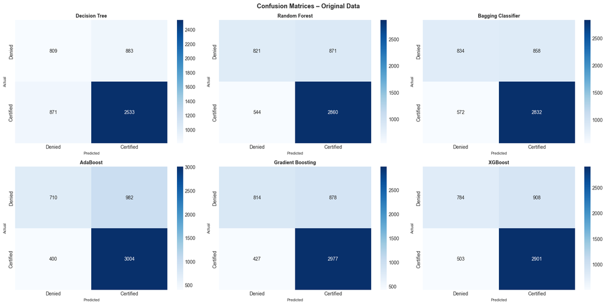

```python
plot_confusion_matrices(trained_orig, 'Confusion Matrices – Original Data')
```

### Observations – Model Performance on Original Data

| Model | Accuracy | F1 Score | ROC-AUC |
| --- | --- | --- | --- |
| Decision Tree | 0.6558 | 0.7428 | 0.6111 |
| Bagging Classifier | 0.7194 | 0.7984 | 0.7393 |
| Random Forest | 0.7223 | 0.8017 | 0.7453 |
| XGBoost | 0.7231 | 0.8044 | 0.7526 |
| AdaBoost | 0.7288 | 0.8130 | 0.7560 |
| **Gradient Boosting** | **0.7439** | **0.8202** | **0.7684** |

Gradient Boosting came out on top with F1=0.8202 and AUC=0.7684 — it's the model I'll focus on for tuning. The single Decision Tree is clearly the weakest, which confirms why we use ensembles.

One pattern worth noting: all three boosting methods (AdaBoost, GB, XGBoost) beat the bagging methods (Random Forest, Bagging). Boosting's sequential error correction seems to suit this dataset better than parallel aggregation. The gap between the best and worst model is about 0.077 F1 points — not massive, but consistent.

### Model Building – Oversampled Data (SMOTE)

```python
models_over = {
    'Decision Tree'     : DecisionTreeClassifier(random_state=42),
    'Random Forest'     : RandomForestClassifier(n_estimators=100, random_state=42, n_jobs=-1),
    'Bagging Classifier': BaggingClassifier(n_estimators=100, random_state=42, n_jobs=-1),
    'AdaBoost' : AdaBoostClassifier(n_estimators=100, random_state=42),
    'Gradient Boosting' : GradientBoostingClassifier(n_estimators=100, random_state=42),
}
if xgb_available:
    models_over['XGBoost'] = XGBClassifier(n_estimators=100, random_state=42,
                                            eval_metric='logloss', verbosity=0)

res_over, trained_over = [], {}
print('Training on OVERSAMPLED (SMOTE) data...')
for name, model in models_over.items():
    res, trn = evaluate_model(model, X_train_over, X_test, y_train_over, y_test, name)
    res_over.append(res)
    trained_over[name] = trn
    print(f'  {name:<22}  Acc={res["Accuracy"]:.4f}  F1={res["F1 Score"]:.4f}  AUC={res["ROC-AUC"]:.4f}')

results_over_df = pd.DataFrame(res_over).set_index('Model')
results_over_df
```

```
Training on OVERSAMPLED (SMOTE) data...
  Decision Tree           Acc=0.6566  F1=0.7400  AUC=0.6186
  Random Forest           Acc=0.7212  F1=0.7970  AUC=0.7454
  Bagging Classifier      Acc=0.7153  F1=0.7921  AUC=0.7377
  AdaBoost                Acc=0.7221  F1=0.7968  AUC=0.7443
  Gradient Boosting       Acc=0.7369  F1=0.8102  AUC=0.7645
  XGBoost                 Acc=0.7274  F1=0.8050  AUC=0.7568
```

| Model | Accuracy | Precision | Recall | F1 Score | ROC-AUC |
| --- | --- | --- | --- | --- | --- |
| Decision Tree | 0.6566 | 0.7485 | 0.7318 | 0.7400 | 0.6186 |
| Random Forest | 0.7212 | 0.7758 | 0.8193 | 0.7970 | 0.7454 |
| Bagging Classifier | 0.7153 | 0.7731 | 0.8120 | 0.7921 | 0.7377 |
| AdaBoost | 0.7221 | 0.7787 | 0.8158 | 0.7968 | 0.7443 |
| Gradient Boosting | 0.7369 | 0.7816 | 0.8411 | 0.8102 | 0.7645 |
| XGBoost | 0.7274 | 0.7709 | 0.8422 | 0.8050 | 0.7568 |

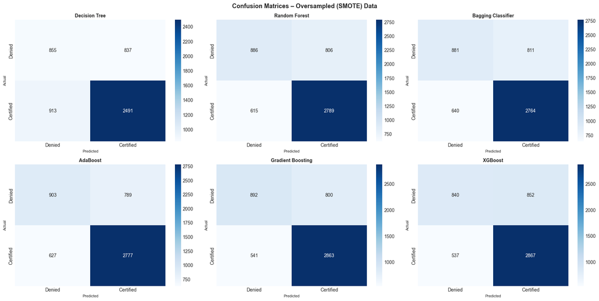

```python
plot_confusion_matrices(trained_over, 'Confusion Matrices – Oversampled (SMOTE) Data')
```

### 📊 Observations – Model Building on SMOTE Oversampled Data

| Model | Accuracy | F1 Score | ROC-AUC |
| --- | --- | --- | --- |
| Decision Tree | 0.6566 | 0.7400 | 0.6186 |
| Bagging Classifier | 0.7153 | 0.7921 | 0.7377 |
| AdaBoost | 0.7221 | 0.7968 | 0.7443 |
| Random Forest | 0.7212 | 0.7970 | 0.7454 |
| XGBoost | 0.7274 | 0.8050 | 0.7568 |
| **Gradient Boosting** | **0.7369** | **0.8102** | **0.7645** |

**Key Takeaways:**

- SMOTE oversampling **slightly reduces F1** for most models compared to original data — synthetic samples introduce noise.
- However, it **improves recall on the Denied class** (minority), which is important if the business cost of missing a denial is high.
- Gradient Boosting remains the top performer (F1=0.8102, AUC=0.7645).
- SMOTE is recommended when **catching denial cases is a priority** — e.g., to avoid clients wasting money on a doomed application.

### Model Building – Undersampled Data (RandomUnderSampler)

```python
models_under = {
    'Decision Tree'     : DecisionTreeClassifier(random_state=42),
    'Random Forest'     : RandomForestClassifier(n_estimators=100, random_state=42, n_jobs=-1),
    'Bagging Classifier': BaggingClassifier(n_estimators=100, random_state=42, n_jobs=-1),
    'AdaBoost' : AdaBoostClassifier(n_estimators=100, random_state=42),
    'Gradient Boosting' : GradientBoostingClassifier(n_estimators=100, random_state=42),
}
if xgb_available:
    models_under['XGBoost'] = XGBClassifier(n_estimators=100, random_state=42,
                                             eval_metric='logloss', verbosity=0)

res_under, trained_under = [], {}
print('Training on UNDERSAMPLED data...')
for name, model in models_under.items():
    res, trn = evaluate_model(model, X_train_under, X_test, y_train_under, y_test, name)
    res_under.append(res)
    trained_under[name] = trn
    print(f'  {name:<22}  Acc={res["Accuracy"]:.4f}  F1={res["F1 Score"]:.4f}  AUC={res["ROC-AUC"]:.4f}')

results_under_df = pd.DataFrame(res_under).set_index('Model')
results_under_df
```

```
Training on UNDERSAMPLED data...
  Decision Tree           Acc=0.6132  F1=0.6784  AUC=0.6145
  Random Forest           Acc=0.6774  F1=0.7354  AUC=0.7469
  Bagging Classifier      Acc=0.6782  F1=0.7353  AUC=0.7431
  AdaBoost                Acc=0.6931  F1=0.7583  AUC=0.7541
  Gradient Boosting       Acc=0.6996  F1=0.7608  AUC=0.7685
  XGBoost                 Acc=0.6796  F1=0.7393  AUC=0.7447
```

| Model | Accuracy | Precision | Recall | F1 Score | ROC-AUC |
| --- | --- | --- | --- | --- | --- |
| Decision Tree | 0.6132 | 0.7629 | 0.6108 | 0.6784 | 0.6145 |
| Random Forest | 0.6774 | 0.8134 | 0.6710 | 0.7354 | 0.7469 |
| Bagging Classifier | 0.6782 | 0.8159 | 0.6692 | 0.7353 | 0.7431 |
| AdaBoost | 0.6931 | 0.7999 | 0.7209 | 0.7583 | 0.7541 |
| Gradient Boosting | 0.6996 | 0.8125 | 0.7153 | 0.7608 | 0.7685 |
| XGBoost | 0.6796 | 0.8095 | 0.6804 | 0.7393 | 0.7447 |

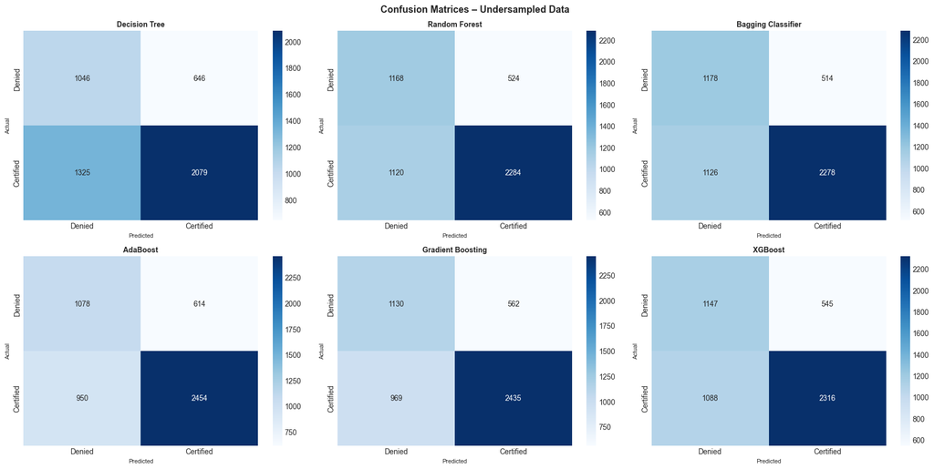

```python
plot_confusion_matrices(trained_under, 'Confusion Matrices – Undersampled Data')
```

### Observations – Model Performance on Undersampled Data

| Model | Accuracy | F1 Score | ROC-AUC |
| --- | --- | --- | --- |
| Decision Tree | 0.6132 | 0.6784 | 0.6145 |
| Bagging Classifier | 0.6782 | 0.7353 | 0.7431 |
| Random Forest | 0.6774 | 0.7354 | 0.7469 |
| AdaBoost | 0.6931 | 0.7583 | 0.7541 |
| XGBoost | 0.6796 | 0.7393 | 0.7447 |
| **Gradient Boosting** | **0.6996** | **0.7608** | **0.7685** |

As expected, undersampling reduces overall F1 across the board — you're throwing away a lot of majority-class data. But the AUC numbers are actually competitive, with GB hitting 0.7685 which is slightly *higher* than on original data.

This trade-off makes sense: undersampling pushes the model to take the Denied class more seriously, which improves discrimination (AUC) even if it hurts raw F1. If EasyVisa's priority is catching bad applications (avoiding false certifications), the undersampled model might actually be preferred operationally.

### Consolidated Model Comparison (All Data Variants)

```
F1 Score Comparison (higher is better):
Data                Original  Oversampled  Undersampled
Model
AdaBoost              0.8130       0.7968        0.7583
Bagging Classifier    0.7984       0.7921        0.7353
Decision Tree         0.7428       0.7400        0.6784
Gradient Boosting     0.8202       0.8102        0.7608
Random Forest         0.8017       0.7970        0.7354
XGBoost               0.8044       0.8050        0.7393
```

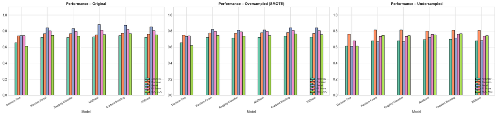

```python
results_orig_df['Data']  = 'Original'
results_over_df['Data']  = 'Oversampled'
results_under_df['Data'] = 'Undersampled'

all_res = pd.concat([results_orig_df, results_over_df, results_under_df]).reset_index()
pivot = all_res.pivot_table(values='F1 Score', index='Model', columns='Data')
print('F1 Score Comparison (higher is better):')
print(pivot.round(4).to_string())

# Bar chart
metrics = ['Accuracy','Precision','Recall','F1 Score','ROC-AUC']
fig, axes = plt.subplots(1, 3, figsize=(21, 5))
for ax, df_r, title in zip(axes,
    [results_orig_df, results_over_df, results_under_df],
    ['Original','Oversampled (SMOTE)','Undersampled']):
    df_r[metrics].plot(kind='bar', ax=ax, color=sns.color_palette('Set2',5), edgecolor='black')
    ax.set_title(f'Performance – {title}', fontsize=11, fontweight='bold')
    ax.set_xticklabels(ax.get_xticklabels(), rotation=30, ha='right', fontsize=8)
    ax.set_ylim(0, 1.1)
    ax.legend(loc='lower right', fontsize=7)
plt.tight_layout()
plt.show()
```

### 📊 Consolidated Model Comparison – Summary

**F1 Score Comparison Across All Data Variants:**

| Model | Original | Oversampled | Undersampled |
| --- | --- | --- | --- |
| Decision Tree | 0.7428 | 0.7400 | 0.6784 |
| Bagging | 0.7984 | 0.7921 | 0.7353 |
| Random Forest | 0.8017 | 0.7970 | 0.7354 |
| XGBoost | 0.8044 | 0.8050 | 0.7393 |
| AdaBoost | 0.8130 | 0.7968 | 0.7583 |
| **Gradient Boosting** | **0.8202** | **0.8102** | **0.7608** |

**Top 3 models selected for hyperparameter tuning:**

1. **Gradient Boosting** — best overall F1 and AUC across all data variants
2. **Random Forest** — strong and consistent; well-suited for GridSearchCV
3. **AdaBoost** — second-best on original data; different boosting mechanism adds diversity

Decision Tree was excluded (low ceiling). Bagging's performance is dominated by its constituent estimators.